# RT-PCR positivity duration

Pablo Perez

19/10/2020

In *[Eurosurveillance 2020 Jul 30; 25(30): 2001292](https://dx.doi.org/10.2807/1560-7917.ES.2020.25.30.2001292)*, Omar et al. analysed data of consecutive RT-qPCR results in 537 symptomatic patients with mild COVID-19 in home quarantine, between 28 February to 6 June 2020 in Rhineland-Palatinate, Germany. Table 1 presents their reported data on the population with an RT-qPCR positive for SARS-CoV-2 RNA at mean (95%CI) days after symptom onset. They reported a **median time to testing negative of 20 days (IQR 16-28)**.

# Table 1. Cumulative population proportions

```r
df[,2:4]
```

```
##    Proportion Number        Mean..95.CI.
## 1       0.990    532    2.24 (1.88-2.61)
## 2       0.975    524    3.31 (2.85-3.77)
## 3       0.950    510    4.48 (3.89-5.07)
## 4       0.900    483    6.15 (5.33-6.97)
## 5       0.750    403   9.74 (8.42-11.07)
## 6       0.500    269  14.96 (13.01-16.9)
## 7       0.250    134 21.43 (18.96-23.91)
## 8       0.100     54  28.28 (25.5-31.06)
## 9       0.050     27 32.82 (29.93-35.72)
## 10      0.025     13    37.01 (34.03-40)
## 11      0.010      5 42.16 (39.04-45.29)
## 12         NA     NA
```

## Simulated study population

For `i in 1:1,000`, at each iteration of time `t`, sample `n` random numbers
$$\ n \ = \space n^{t} \ - n^{t-1}$$
from a normal distribution with mean = `mu` and sd = `sigma`, given upper and lower bounds of observed time.

At each step `i`, fit a gamma distribution by maximum likelihood, obtain its parameters and then average across all 1,000 iterations.

```
## [1] "Shape = "         "3.43248795446714"
```

```
## [1] "Scale = "         "5.57980677561458"
```

```
## [1] "Rate = "           "0.179217675488388"
```

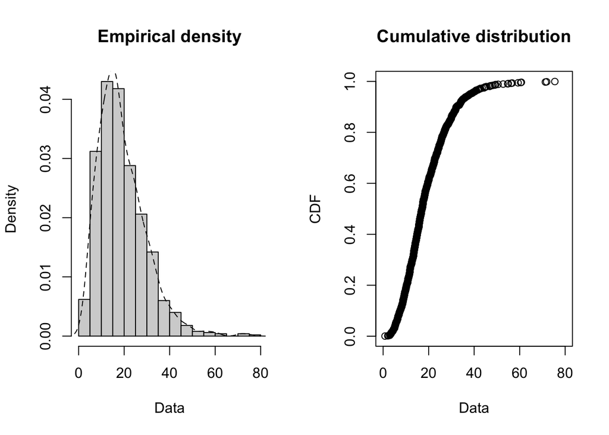

```
##    Min. 1st Qu.  Median    Mean 3rd Qu.    Max.
##  0.8405 11.6889 17.1083 19.0792 24.7015 75.4505
```

## Fit distribution directly

Using Omar et al.’s reported cumulative `proportion` and `mean` time, fit distribution lines and obtain parameters.

```
## The fitting procedure 'L-BFGS-B' was successful!
```

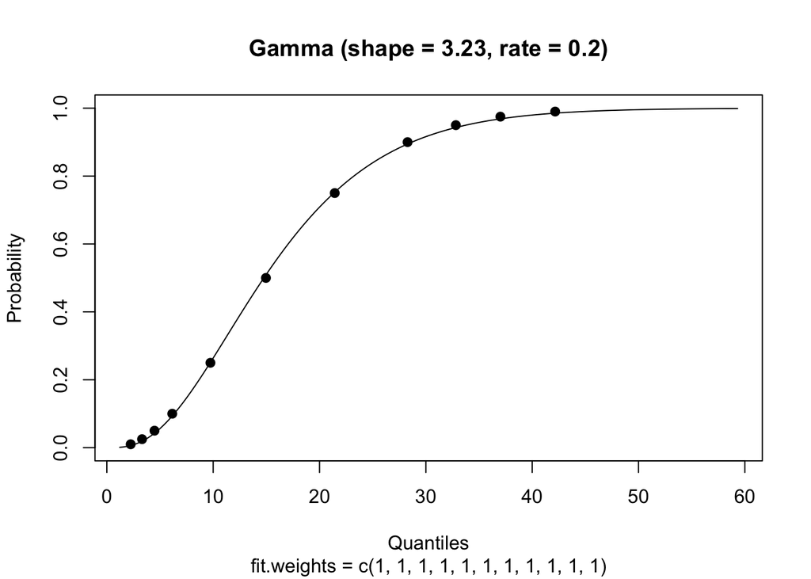

```
##    shape     rate
## 3.229555 0.196583
```

```r
get.gamma.par(p, q, show.output = FALSE, plot = TRUE, tol = 0.001)
```

Obtain a gamma distributed random sample of `n = 1000` and test distribution fit.

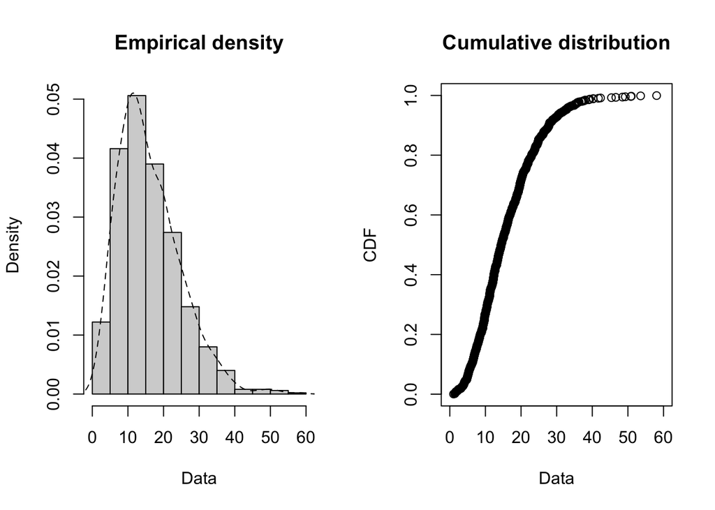

```
##    Min. 1st Qu.  Median    Mean 3rd Qu.    Max.
##   1.046   9.712  14.395  16.044  21.047  58.053
```